# Identification and analysis of SARS-CoV-2-specific T-cell receptors\: Epitope classification

Andrey Sobolev, Artyom Ershov

6/10/2021

This R Markdown document briefly describes a workflow of comparing algorithms for TCR classification (tcrdist3 and GLIPH2) to tell coronavirus epitopes from other virus-specific epitopes.

# 0. Custom functions definition

Here, we define a custom function to plot a confusion matrix that will be used later in the downstream analysis. Arguments: `df.true` - dataframe with true values, `df.pred` - dataframe with predicted values, `title` - main title of the resulting plot, `true.lab` - label of the true class, `pred.lab` - label of the predicted class, `high.col` and `low.col` define color scale for the plot.

```r
#--------custom functions--------
# function to plot confusion matrix. taken from https://stackoverflow.com/a/66606295
conf_matrix <- function(df.true, df.pred, ba, title = "", true.lab ="True Class", pred.lab ="Predicted Class",
                        high.col = 'red', low.col = 'white') {
  #convert input vector to factors, and ensure they have the same levels
  df.true <- as.factor(df.true)
  df.pred <- factor(df.pred, levels = levels(df.true))

  #generate confusion matrix, and confusion matrix as a pecentage of each true class (to be used for color)
  df.cm <- table(True = df.true, Pred = df.pred)
  df.cm.col <- df.cm / rowSums(df.cm)

  #convert confusion matrices to tables, and binding them together
  df.table <- reshape2::melt(df.cm)
  df.table.col <- reshape2::melt(df.cm.col)
  df.table <- left_join(df.table, df.table.col, by =c("True", "Pred"))

  #calculate accuracy and class accuracy
  acc.vector <- c(diag(df.cm)) / c(rowSums(df.cm))
  class.acc <- data.frame(Pred = "Class Acc.", True = names(acc.vector), value = acc.vector)
  acc <- sum(diag(df.cm)) / sum(df.cm)

  #plot
  ggplot() +
    geom_tile(aes(x=Pred, y=True, fill=value.y),
              data=df.table, size=0.2, color=grey(0.5)) +
    geom_tile(aes(x=Pred, y=True),
              data=df.table[df.table$True==df.table$Pred, ], size=1, color="black", fill = 'transparent') +
    scale_x_discrete(position = "top",  limits = c(levels(df.table$Pred), "Class Acc.")) +
    scale_y_discrete(limits = rev(unique(levels(df.table$Pred)))) +
    labs(x=pred.lab, y=true.lab, fill=NULL,
         title= paste0(title, "\nAccuracy ", round(100*acc, 1), "%\n")) +
    geom_text(aes(x=Pred, y=True, label=value.x),
              data=df.table, size=4, colour="black") +
    geom_text(data = class.acc, aes(Pred, True, label = paste0(round(100*value), "%"))) +
    scale_fill_gradient(low=low.col, high=high.col, labels = scales::percent,
                        limits = c(0,1), breaks = c(0,0.5,1)) +
    guides(size=F) +
    theme_bw() +
    theme(panel.border = element_blank(), legend.position = "bottom",
          axis.text = element_text(color='black'), axis.ticks = element_blank(),
          panel.grid = element_blank(), axis.text.x.top = element_text(angle = 30, vjust = 0, hjust = 0)) +
    coord_fixed()

}
```

Then, let’s attach prerequisite packages.

```r
pckgs <- c('data.table', 'dplyr', 'tidyr', 'ggplot2', 'patchwork', 'pROC', 'stringr')
for(i in pckgs){
  if(!require(i, character.only = T)){
    install.packages(i, dependencies = T)
    library(i)
  }
}
```

# 1. Data preprocessing

For the analysis, VDJdb was used. It is stored in the repository under the name `vdjdb.slim.txt`. To use it in the analysis, one must specify a valid path to the VDJdb.

```r
path <- './'
vdjdb <- fread(paste0(path, 'vdjdb.slim.txt'))
str(vdjdb)
```

```
## Classes 'data.table' and 'data.frame':   63512 obs. of  16 variables:
##  $ gene           : chr  "TRB" "TRB" "TRB" "TRA" ...
##  $ cdr3           : chr  "CASSTSRLSNQPQYF" "CASSQDRGPANEQFF" "CASSMSRSSNQPQYF" "CASNTGTASKLTF" ...
##  $ species        : chr  "MacacaMulatta" "HomoSapiens" "MacacaMulatta" "HomoSapiens" ...
##  $ antigen.epitope: chr  "STPESANL" "RLRAEAQVK" "TTPESANL" "GILGFVFTL" ...
##  $ antigen.gene   : chr  "Tat" "EBNA3A" "Tat" "M" ...
##  $ antigen.species: chr  "SIV" "EBV" "SIV" "InfluenzaA" ...
##  $ complex.id     : chr  "0" "20240" "0" "0" ...
##  $ v.segm         : chr  "TRBV14*01" "TRBV4-1*01" "TRBV14*01" "TRAV24*01" ...
##  $ j.segm         : chr  "TRBJ1-5*01" "TRBJ2-1*01" "TRBJ1-5*01" "TRAJ44*01" ...
##  $ v.end          : int  4 5 4 2 5 3 3 4 5 3 ...
##  $ j.start        : int  8 10 8 3 6 10 5 13 9 6 ...
##  $ mhc.a          : chr  "Mamu-A*01" "HLA-A*03:01" "Mamu-A*01" "HLA-A*02" ...
##  $ mhc.b          : chr  "B2M" "B2M" "B2M" "B2M" ...
##  $ mhc.class      : chr  "MHCI" "MHCI" "MHCI" "MHCI" ...
##  $ reference.id   : chr  "PMID:19349463" "https://www.10xgenomics.com/resources/application-notes/a-new-way-of-exploring-immunity-linking-highly-multiple"| __truncated__ "PMID:15589168" "PMID:28423320" ...
##  $ vdjdb.score    : int  1 0 0 0 1 0 0 0 0 0 ...
##  - attr(*, ".internal.selfref")=<externalptr>
```

```r
vdjdb <- vdjdb[-grep('10x', vdjdb$reference.id),] %>%
  filter(gene == 'TRB', species == 'HomoSapiens') %>% filter(
         (str_starts(antigen.epitope, 'YLQ') & str_starts(mhc.a, 'HLA-A\\*02'))
         | (str_starts(antigen.epitope, 'GLC') & str_starts(mhc.a, 'HLA-A\\*02'))
         | (str_starts(antigen.epitope, 'GIL') & str_starts(mhc.a, 'HLA-A\\*02'))
         | (str_starts(antigen.epitope, 'NLV') & str_starts(mhc.a, 'HLA-A\\*02')))
vdjdb$clonotype <- seq(1:nrow(vdjdb))
```

After initial filtering of the database, it is necessary to format the data properly for tcrdist3 and GLIPH2.

## 1.1. tcrdist3 formatting

Briefly, the `count` column is defined, then some columns are renamed and necessary columns are selected. See tcrdist3 documentation on https://tcrdist3.readthedocs.io/ for detailed explanations. After writing the results into a file, we rename the created variable so as not to litter the workspace.

```r
tcrdist3_input <- vdjdb %>%
  mutate(cohort = ifelse(antigen.species == 'SARS-CoV-2', 'CoV', 'non-CoV'),
         count = 1) %>% rename(epitope = antigen.epitope,
                               v_b_gene = v.segm,
                               j_b_gene = j.segm,
                               cdr3_b_aa = cdr3,
                               subject = clonotype) %>%
  select(subject, epitope, count, v_b_gene, j_b_gene, cdr3_b_aa)
write.table(tcrdist3_input, paste0(path, 'tcrdist3/tcrdist3_input.tsv'), sep = '\t',
            quote = F, row.names = F, col.names = T)
rm(tcrdist3_input)
```

## 1.2. GLIPH2 formatting

The same is done for GLIPH2. For details, please visit GLIPH2 documentation at http://50.255.35.37:8080.

```r
gliph2_input <- vdjdb %>%
  mutate(cohort = ifelse(antigen.species == 'SARS-CoV-2', 'CoV', 'non-CoV'),
         count = 1) %>% rename(CDR3b = cdr3,
                               TRBV = v.segm,
                               TRBJ = j.segm,
         ) %>% unite('subject:condition', clonotype:cohort, sep=':') %>%
  mutate(count = 1, CDR3a = NA) %>%
  select(CDR3b, TRBV, TRBJ, CDR3a, 'subject:condition', count)

write.table(gliph2_input, paste0(path, 'gliph2/gliph2_input.tsv'), sep = '\t',
            quote = F, row.names = F, col.names = T)
rm(gliph2_input)
```

## Launching the algorithms

tcrdist3 was launched using the Python script `tcrdist3_clustering.py`. See its description in README (**Methods**, **Description and Usage** sections) for details. GLIPH2 was launched using the web interface at http://50.255.35.37:8080. See README (**Methods**, **Description and Usage** sections) for detailed explanation of the parameters.

Resulting files are stored in the repository in corresponding folders. GLIPH2 results are stored under the name `gliph2_output_raw.csv`, tcrdist3 results are under the name `centroids_df.csv`.

# 2. GLIPH2 analysis

Load the results:

```r
gliph2 <- fread(paste0(path, 'gliph2/gliph2_output_raw.csv'), fill = T)
```

Now, we tidy up the results for convenience and filter out the clusters with <10 members.

```r
gliph2 <- gliph2 %>% separate(Sample, c('clonotype', NA), ':') %>%  # extract clonotypes' IDs
  mutate_at('clonotype', as.numeric) %>%   # convert to numeric
  group_by(index) %>% rename(cluster = index) %>%  # group by cluster
  mutate(ulTcRb = as.factor(ulTcRb)) %>%
  select(-TcRa) %>% filter(!is.na(cluster)) %>% rename(cdr3 = TcRb) %>%
  filter(number_unique_cdr3 >= 10)
```

Next, we merge it with the initial database to retrieve information on epitopes corresponding to these TCRs.

```r
preds <- merge(gliph2, vdjdb, by = c('clonotype', 'cdr3'), all.y = T) %>% # set all.y to T to complete
  select(clonotype, cdr3, antigen.species, antigen.epitope, cluster) %>%  # choose only necessary columns
  rename(species = antigen.species, epitope = antigen.epitope) %>%
  mutate_at('species', as.factor)
preds$cluster[which(is.na(preds$cluster))] <- 0  # set cluster of unclassified samples to 0
```

To estimate the probabilities of assigning each epitope to its cluster, we term the share of each epitope in the corresponding cluster as “epitope weight” and attach these weights to the dataframe with predictions. We then check the correctness of the predictions by adding `correct_epitope` column.

```r
weights <- preds %>% group_by(cluster, epitope) %>% count(epitope) %>%
  group_by(cluster) %>%
  summarize(cluster = cluster, epitope = epitope, epitope_weight = n / sum(n),
            predicted_epitope = epitope[which.max(epitope_weight)])

# attach to the initial dataframe
preds <- merge(weights, preds, by = c('cluster', 'epitope'))
preds$correct_epitope <- ifelse(preds$epitope == preds$predicted_epitope, TRUE, FALSE)
```

IMPORTANT: After that, we remove clonotypes that were assigned to multiple clusters. To avoid it, comment the line with `%>% filter(n == 1)`. Line with " %>% filter(n == 1)" can be either commented or uncommented depending on whether you want to remove clonotypes that were assigned to multiple clusters (yes, GLIPH2 clusters TCRs this way).

After that, columns for binary classification estimation are prepared.

```r
preds <-merge(preds, count(preds, clonotype)) %>% filter(n == 1)

preds$correct_epitope[which(preds$cluster == 0)] <- FALSE
preds$predicted_epitope[which(preds$cluster == 0)] <- 'None'
preds <- preds %>%
  mutate_at(c('epitope', 'predicted_epitope'), as.factor) %>%
  mutate(ylq_real = ifelse(str_starts(epitope, 'YLQ'), 'YLQ', 'Not_YLQ'),
         ylq_pred = ifelse(str_starts(predicted_epitope, 'YLQ'), 'YLQ', 'Not_YLQ')) %>%
  mutate_at(c('ylq_real', 'ylq_pred'), as.factor) %>%
  mutate(ylq_correct = ifelse(ylq_real == ylq_pred, TRUE, FALSE))
```

We use pROC library for the classification.

## 2.1. Multi-class classification: ROC, PRC

```r
gliph2_multiclass_roc <- multiclass.roc(preds$epitope, preds$epitope_weight)
print(auc(gliph2_multiclass_roc))
```

```
## Multi-class area under the curve: 0.8785
```

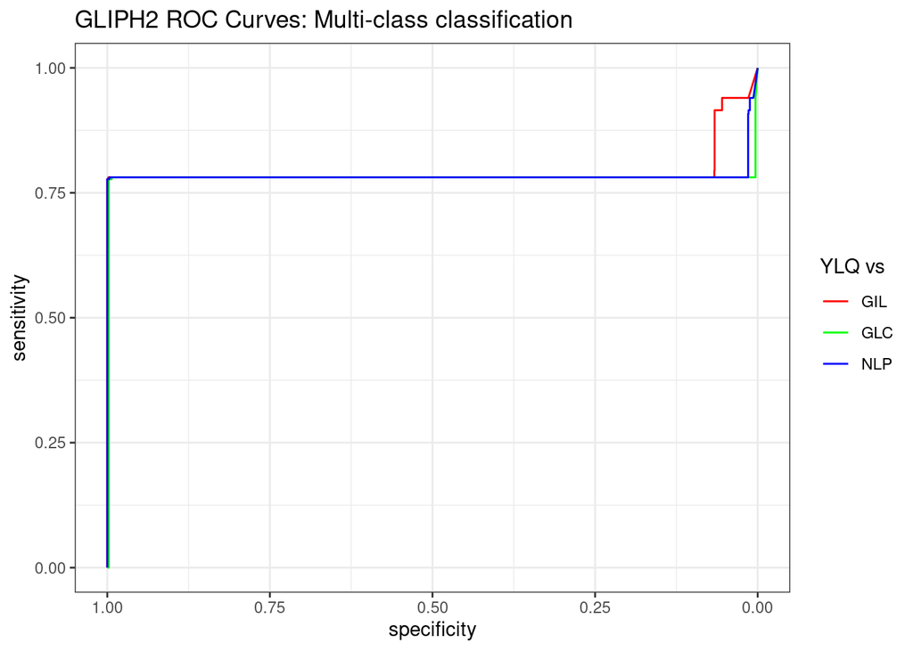

```r
rs_gliph2 <- gliph2_multiclass_roc[['rocs']][c(3, 5, 6)]  # list of roc curves
pr_curves_gliph2 <- lapply(c(1:3), function (i)
  coords(rs_gliph2[[i]], 'all', ret = c('recall', 'precision', 'threshold'), transpose = FALSE))  # list of data for PRC

roc_gliph2_multiclass_plot <- ggroc(rs_gliph2) + theme_bw() + scale_color_manual(name="YLQ vs",
                                                                                 labels=c("GIL","GLC","NLP"),
                                                                                 values=c("red","green","blue")) +
  ggtitle('GLIPH2 ROC Curves: Multi-class classification')

pr_curves_gliph2[[1]]$response <- 'GIL'
pr_curves_gliph2[[2]]$response <- 'GLC'
pr_curves_gliph2[[3]]$response <- 'NLP'

pr_gliph2 <- rbind(pr_curves_gliph2[[1]], pr_curves_gliph2[[2]], pr_curves_gliph2[[3]])
pr_gliph2_multiclass_plot <- ggplot(pr_gliph2, aes(recall, precision, color = response)) + geom_path(aes(recall, precision)) + coord_equal() +
  theme_bw() + scale_color_manual(name='YLQ vs',
                                  values=c('red', 'green', 'blue')) +
  ggtitle('GLIPH2 PR Curves: Multi-class classification')
roc_gliph2_multiclass_plot
```

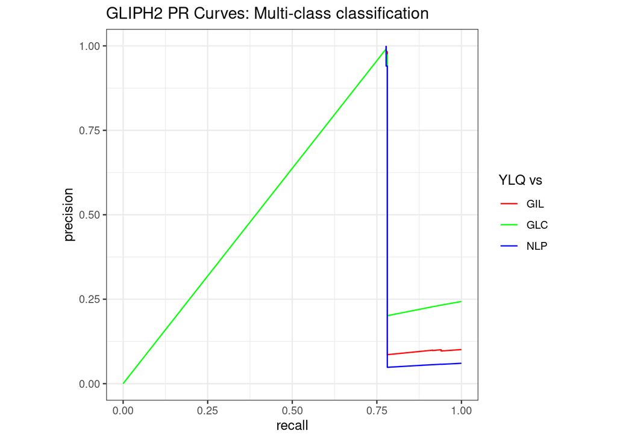

```r
pr_gliph2_multiclass_plot
```

## 2.2. Binary classification: ROC, PRC

```r
gliph2_binary_roc <- roc(preds$ylq_real, preds$epitope_weight)
print(auc(gliph2_binary_roc))
```

```
## Area under the curve: 0.7856
```

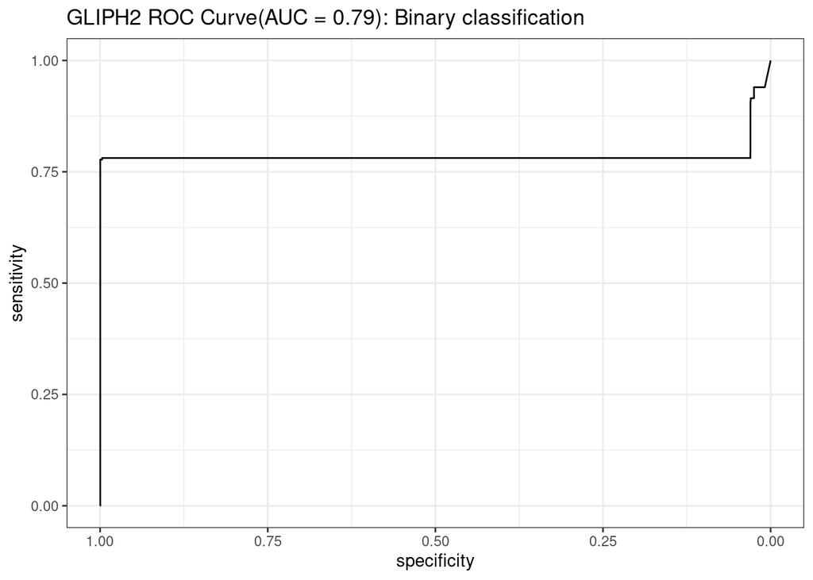

```r
binary_roc_gliph2_plot <- ggroc(gliph2_binary_roc) + theme_bw() + ggtitle(paste0('GLIPH2 ROC Curve(AUC = ', round(auc(gliph2_binary_roc),2), '): Binary classification'))
pr1 <- coords(gliph2_binary_roc, 'all', ret = c('recall', 'precision', 'threshold'), transpose = F)
binary_prc_gliph2_plot <- ggplot(pr1, aes(recall, precision)) + geom_path(aes(recall, precision)) + coord_equal() +
  theme_bw() + ggtitle('GLIPH2 PR Curve: Binary classification')
binary_roc_gliph2_plot
```

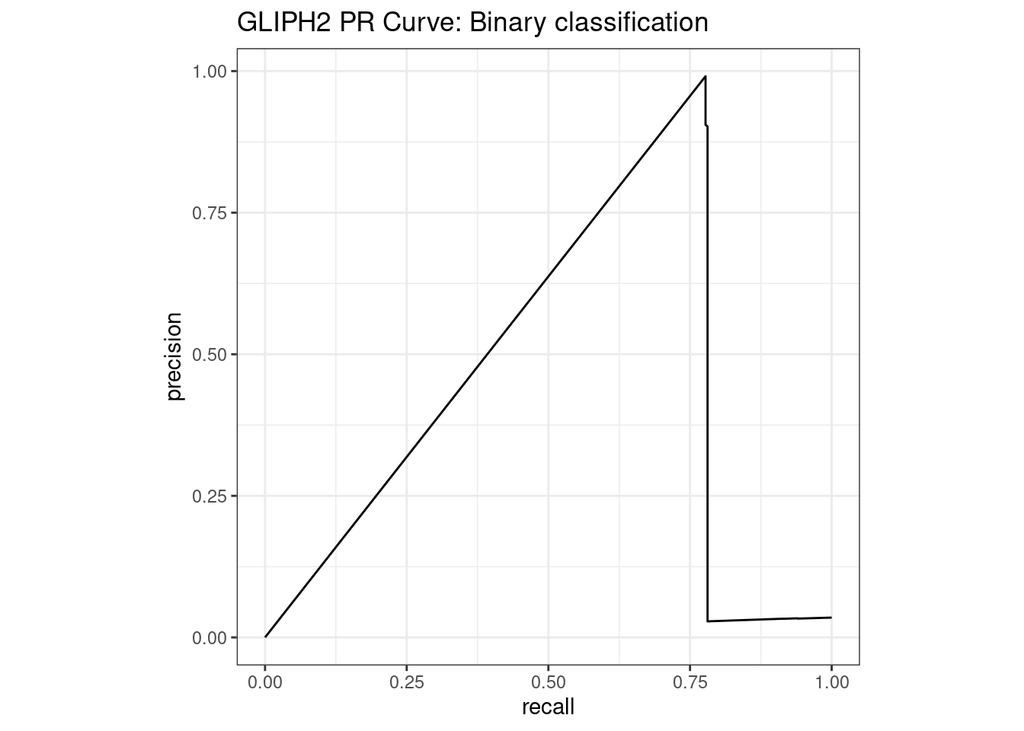

```r
binary_prc_gliph2_plot
```

# 2.3. Confusion matrices

Here, we will use our custom function created at the beginning.

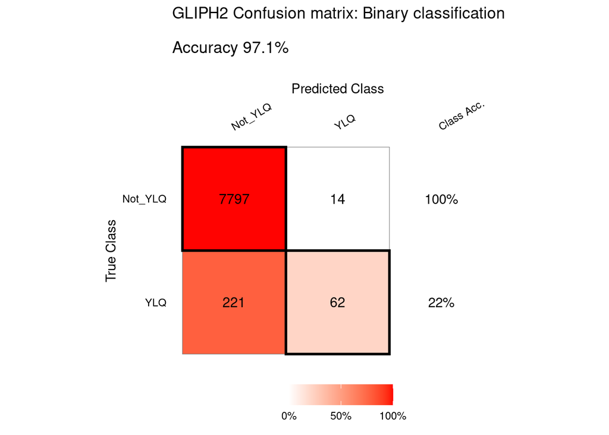

```r
gliph2_binary_cm <- conf_matrix(preds$ylq_real,
                                preds$ylq_pred,
                                title = 'GLIPH2 Confusion matrix: Binary classification\n')
gliph2_multiclass_cm <- conf_matrix(preds$epitope,
                                    preds$predicted_epitope,
                                    title='GLIPH2: Confusion matrix: Multi-class classification\n')

gliph2_binary_cm
```

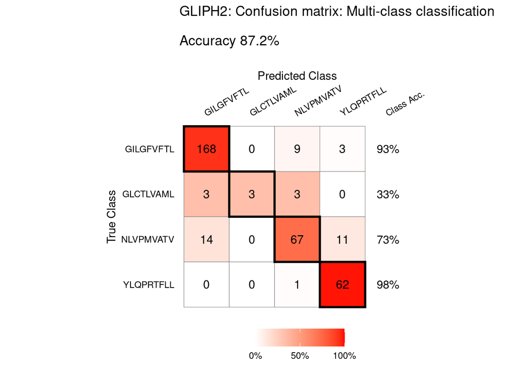

```r
gliph2_multiclass_cm
```

# 3. tcrdist3 analysis

Same ideas are used here except for the slightly different data preprocessing and filtration. That is why this section will be barely described. For details, please see section 2.

Load data:

```r
tcrdist3 <- fread(paste0(path, 'tcrdist3/centroids_df.csv'))
```

Tidy up and summarize the results:

```r
tcrdist3$neighbors <- gsub('\\[|\\]', '', tcrdist3$neighbors)
summ <- tcrdist3 %>% separate_rows(neighbors, sep = ',') %>%
  group_by(epitope) %>% summarize(cluster = cluster_id,
                                  clonotype = as.numeric(neighbors))
```

Merge with the initial database and assign columns for classification estimation:

```r
res <- merge(summ, vdjdb, by = 'clonotype') %>%
  select(clonotype, cluster, epitope, antigen.epitope, antigen.species) %>%
  rename(predicted_epitope = epitope, epitope = antigen.epitope, Species = antigen.species) %>%
  group_by(cluster, epitope) %>% mutate(num = n()) %>%
  group_by(cluster) %>%
  summarize(cluster = cluster, epitope = epitope, epitope_weight = num / sum(num),
            predicted_epitope = predicted_epitope, clonotype = clonotype,
            Species = Species) %>% arrange(cluster) %>%
  mutate(predicted_epitope = epitope[which.max(epitope_weight)]) %>%
  mutate(ylq_real = ifelse(str_starts(epitope, 'YLQ'), 'YLQ', 'Not_YLQ'),
         ylq_pred = ifelse(str_starts(predicted_epitope, 'YLQ'), 'YLQ', 'Not_YLQ')) %>%
  mutate_at(c('ylq_real', 'ylq_pred', 'epitope', 'predicted_epitope'), as.factor) %>%
  mutate(ylq_correct = ifelse(ylq_real == ylq_pred, TRUE, FALSE))
```

# 3.1. Multi-class classification: ROC, PRC

```r
tcrdist3_multiclass_roc <- multiclass.roc(res$epitope, res$epitope_weight)
auc(tcrdist3_multiclass_roc)
```

```
## Multi-class area under the curve: 0.799
```

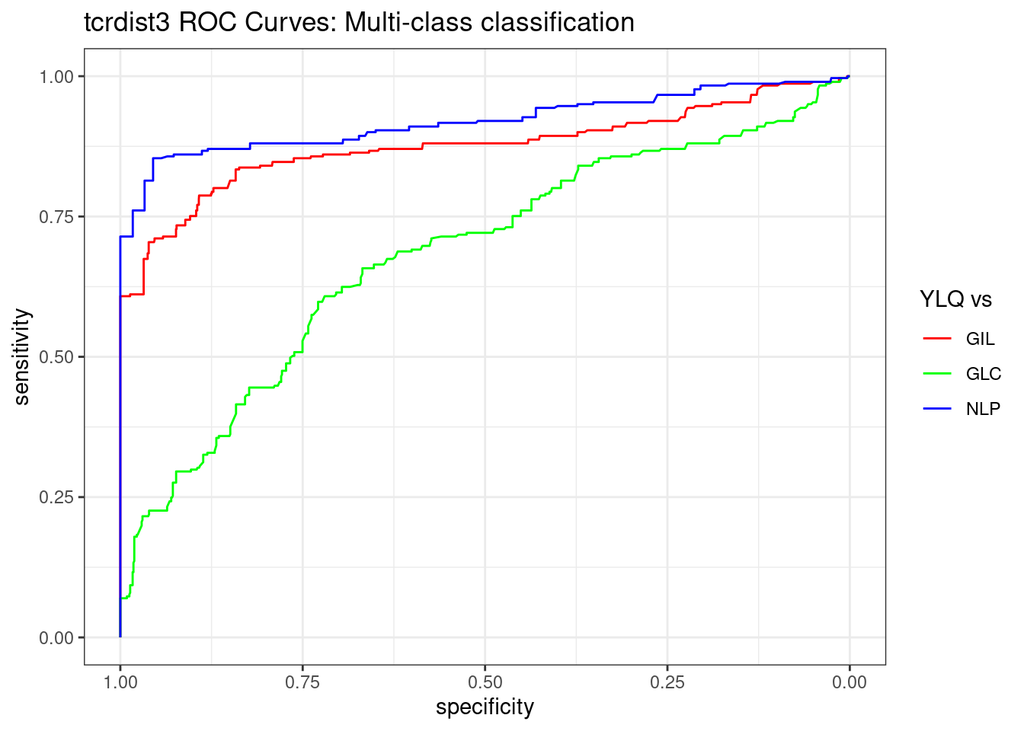

```r
rs_tcrdist <- tcrdist3_multiclass_roc[['rocs']][c(3, 5, 6)]  # list of roc curves
pr_curves_tcrdist <- lapply(c(1:3), function (i)
  coords(rs_tcrdist[[i]], 'all', ret = c('recall', 'precision', 'threshold'), transpose = FALSE))  # list of data for PRC

roc_tcrdist3_multiclass_plot <- ggroc(rs_tcrdist) + theme_bw() + scale_color_manual(name="YLQ vs",
                                                                                    labels=c("GIL","GLC","NLP"),
                                                                                    values=c("red","green","blue")) +
  ggtitle('tcrdist3 ROC Curves: Multi-class classification')

pr_curves_tcrdist[[1]]$response <- 'GIL'
pr_curves_tcrdist[[2]]$response <- 'GLC'
pr_curves_tcrdist[[3]]$response <- 'NLP'

pr_tcrdist3 <- rbind(pr_curves_tcrdist[[1]], pr_curves_tcrdist[[2]], pr_curves_tcrdist[[3]])
pr_tcrdist3_multiclass_plot <- ggplot(pr_tcrdist3, aes(recall, precision, color = response)) + geom_path(aes(recall, precision)) + coord_equal() +
  theme_bw() + scale_color_manual(name='YLQ vs',
                                  values=c('red', 'green', 'blue')) +
  ggtitle('tcrdist3 PR Curves: Multi-class classification')
roc_tcrdist3_multiclass_plot
```

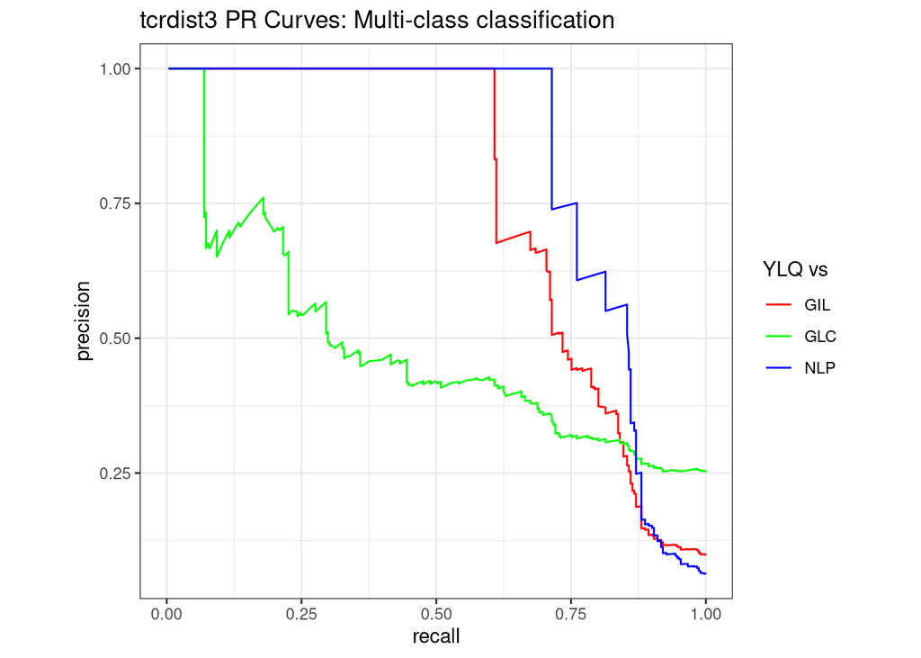

```r
pr_tcrdist3_multiclass_plot
```

# 3.2. Binary classification: ROC, PRC

```r
tcrdist3_binary_roc <- roc(res$ylq_real, res$epitope_weight)
auc(tcrdist3_binary_roc)
```

```
## Area under the curve: 0.8787
```

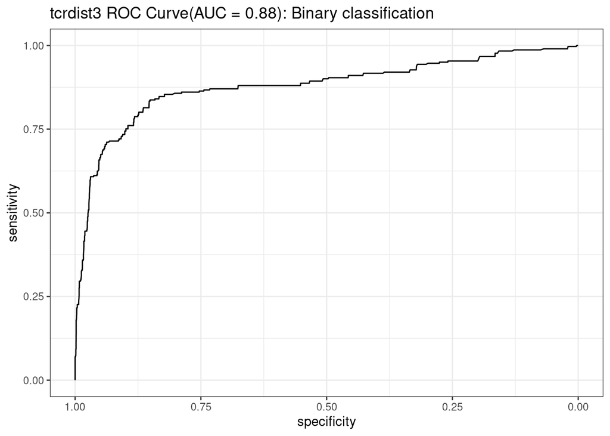

```r
roc_tcrdist3_binary_plot <- ggroc(tcrdist3_binary_roc) + theme_bw() + ggtitle(paste0('tcrdist3 ROC Curve(AUC = ', round(auc(tcrdist3_binary_roc),2), '): Binary classification'))
pr <- coords(tcrdist3_binary_roc, 'all', ret = c('recall', 'precision', 'threshold'), transpose = F)
prc_tcrdist3_binary_plot <- ggplot(pr, aes(recall, precision)) + geom_path(aes(recall, precision)) + coord_equal() +
  theme_bw() + ggtitle('tcrdist3 PR Curve: Binary classification')
roc_tcrdist3_binary_plot
```

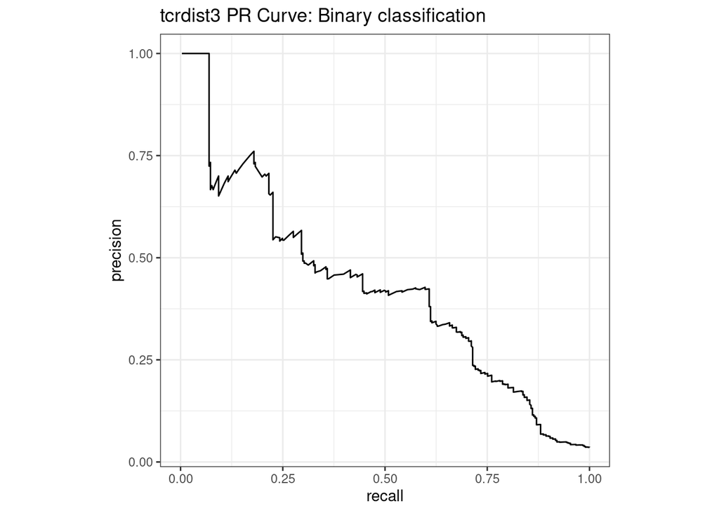

```r
prc_tcrdist3_binary_plot
```

# 3.3. Confusion matrices

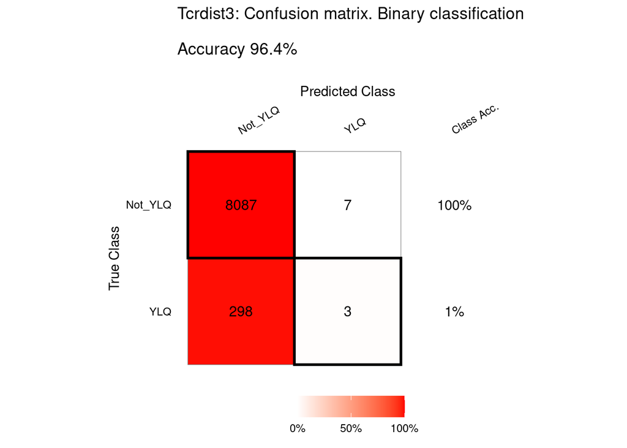

```r
tcrdist3_binary_cm <- conf_matrix(res$ylq_real,
                                  res$ylq_pred,
                                  title = 'Tcrdist3: Confusion matrix. Binary classification\n')
tcrdist3_multiclass_cm <- conf_matrix(res$epitope, res$predicted_epitope,
                                      title = 'Tcrdist3 Confusion matrix. Multi-class classification\n')
tcrdist3_binary_cm
```

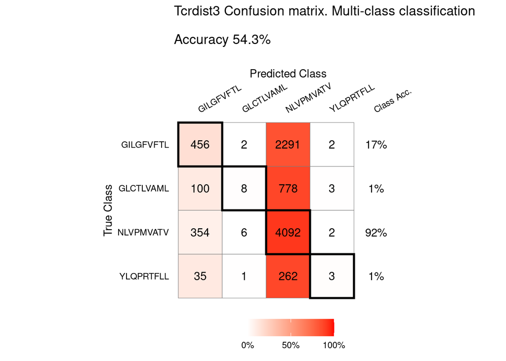

```r
tcrdist3_multiclass_cm
```